# Probabilistic Programming in Python

# Where's the catch?

[figure not shown]

In most interesting cases, we can't solve what is inside the Bayesian box.

# Probabilistic Programming

- If we can't solve something, **approximate** it.
- Markov-Chain Monte Carlo (MCMC) instead draws **samples** from the posterior.
- Fortunately, this algorithm can be applied to almost any model.

## Approximating the posterior with MCMC sampling

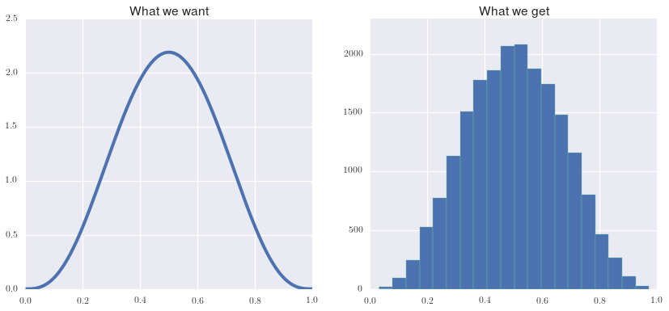

```python
plot_approx()
```

# PyMC3

- Probabilistic Programming framework written in Python.
- Allows for construction of probabilistic models using intuitive syntax.
- Features advanced MCMC samplers.
- Just-in-time compiled by Theano.
- **Extensible**: easily incorporates custom MCMC algorithms and unusual probability distributions.
- Written by: John Salvatier, Chris Fonnesbeck, Thomas Wiecki
- Currently still in alpha (few bugs but mainly missing docs).

## Some necessary formalism:

$\theta_a \sim Beta(5, 5)$

$\theta_b \sim Beta(5, 5)$

$data_a \sim Bernoulli(\theta_a)$

$data_b \sim Bernoulli(\theta_b)$

- $\theta$ represents the unkown cause we want to infer, but can't observe directly.
- We write a *generative* story of how this unknown cause relates to observable data.
- Use Bayes to *invert* this generative story and infer *hidden causes* from *observations* -- updating our beliefs about $\theta$.

```python
np.random.seed(9)
algo_a = sp.stats.bernoulli(.5).rvs(300) # 50% profitable days
algo_b = sp.stats.bernoulli(.6).rvs(300) # 60% profitable days
```

[output not shown]

```python
import pymc as pm
model = pm.Model()
with model: # model specifications in PyMC3 are wrapped in a with-statement
    # Define random variables
    theta_a = pm.Beta('theta_a', alpha=5, beta=5) # prior
    theta_b = pm.Beta('theta_b', alpha=5, beta=5) # prior

    # Define how data relates to unknown causes
    data_a = pm.Bernoulli('observed A',
                          p=theta_a,
                          observed=algo_a)

    data_b = pm.Bernoulli('observed B',
                          p=theta_b,
                          observed=algo_b)

    # Inference!
    start = pm.find_MAP() # Find good starting point
    step = pm.Slice() # Instantiate MCMC sampling algorithm
    trace = pm.sample(10000, step, start=start, progressbar=False) # draw posterior samples using slice sampling
```

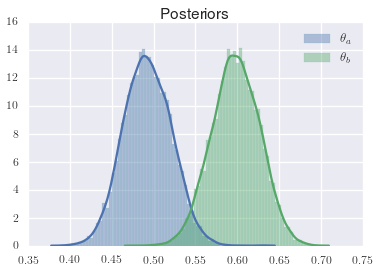

```python
sns.distplot(trace['theta_a'], label=r'$\theta_a$')
sns.distplot(trace['theta_b'], label=r'$\theta_b$')
plt.title('Posteriors')
plt.legend()
```

## Hypothesis testing is trivial

```python
p_b_better_than_a = np.mean(trace['theta_a'] < trace['theta_b'])
print 'Probability that algo B is better than A = %.2f%%' % (p_b_better_than_a * 100)
```

```
Probability that algo B is better than A = 99.11%
```

# Advanced example -- hierarchical models

- Consider that instead of 2 algorithms, we have 20.
- Before we considered that $\theta_a$ and $\theta_b$ are completely independent.
- In reality, while they will probably be different, they will also have similarities.
- We can use *hierarchical modeling* to infer individual algorithms, but also their group distribution.

# Unpooled

[figure not shown]

# Pooled

[figure not shown]

# Partially pooled -- hierarchical

[figure not shown]

```python
np.random.seed(9)
algos = []
algos_idx = []
samples = 300
for i, p_algo in enumerate(sp.stats.beta(10, 10).rvs(20)):
    algos.append(sp.stats.bernoulli(p_algo).rvs(samples))
    algos_idx.append(np.ones(samples) * i)

algos = np.asarray(algos)
algos_idx = np.asarray(algos_idx, dtype=np.int)
print algos.shape
print algos
print algos_idx
```

```
(20, 300)
[[0 1 1 ..., 1 0 0]
 [0 1 1 ..., 0 1 0]
 [1 1 1 ..., 1 1 1]
 ...,
 [1 0 0 ..., 1 0 1]
 [0 1 1 ..., 0 0 0]
 [1 1 0 ..., 0 1 0]]
[[ 0  0  0 ...,  0  0  0]
 [ 1  1  1 ...,  1  1  1]
 [ 2  2  2 ...,  2  2  2]
 ...,
 [17 17 17 ..., 17 17 17]
 [18 18 18 ..., 18 18 18]
 [19 19 19 ..., 19 19 19]]
```

```python
with pm.Model() as model: # model specifications in PyMC3 are wrapped in a with-statement
    # Define random variables
    grp_mean = pm.Beta('grp mean', alpha=2, beta=2) # prior
    grp_scale = pm.Gamma('grp scale', alpha=1, beta=10./10**2) # prior

    # Transform
    alpha = grp_mean * grp_scale
    beta = (1 - grp_mean) * grp_scale

    # Individual random variables, vector of lenght 20
    theta = pm.Beta('theta', alpha=alpha, beta=beta, shape=20)

    # Define how data relates to unknown causes
    data = pm.Bernoulli('observed',
                        p=theta[algos_idx],
                        observed=algos)

    # Inference!
    start = pm.find_MAP() # Find good starting point
    step = pm.NUTS (scaling=start) # Instantiate MCMC sampling algorithm
    trace = pm.sample(10000, step, start=start, progressbar=False)[:2000] # draw posterior samples using slice sampling
```

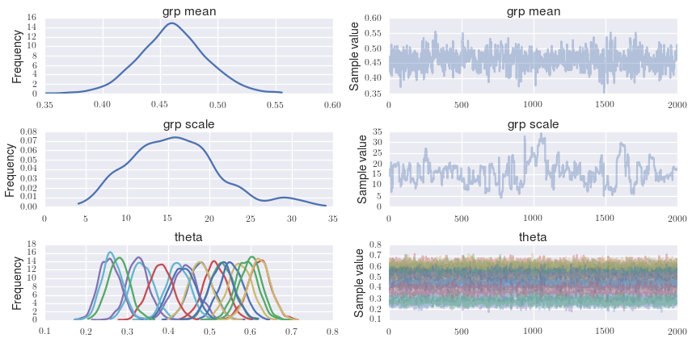

```python
pm.traceplot(trace);
```

# Conclusions

- **Probabilistic Programming** allows you to tell a **genarative story**.
- **Blackbox inference algorithms** allow estimation of **complex models**.
- **PyMC3** puts **advanced samplers** at your fingertips.

# Outstanding Issues

Scalability

- Variational Inference
- see also Max Welling's work for scaling MCMC

Usability

- still too difficult to use
- wanted: library on top of PyMC3 with common models

# Further reading

- [Quantopian](https://www.quantopian.com) -- Develop trading algorithms in Python in your browser.
- [My blog on all things Bayesian](https://twiecki.github.io)
- Twitter: [@twiecki](https://twitter.com/twiecki)
- [Probilistic Programming for Hackers](http://camdavidsonpilon.github.io/Probabilistic-Programming-and-Bayesian-Methods-for-Hackers/) -- IPython Notebook book on Bayesian stats using PyMC2.
- [Doing Bayesian Data Analysis](http://www.indiana.edu/~kruschke/DoingBayesianDataAnalysis/) -- Great book by Kruschke.
- [Get PyMC3 alpha](https://github.com/pymc-devs/pymc/tree/pymc3)
- [IPython Notebook underlying this talk](https://rawgithub.com/twiecki/pymc3_talk/master/bayesian_pymc3.ipynb)